# R语言ggplot2基础教程

## 了解ggplot语法

如果你是一个初学者或者主要使用基础图形，那么构建 ggplot 的语法可能会让人感到困惑。主要的区别在于，与基础图形不同的是，ggplot的工作对象是数据框，而不是单个的向量。所有的数据通常包含在gggplot()提供的数据框中，或者可以提供给各自的geoms。更多的内容将在后面介绍。

第二个值得注意的特点是，你可以通过在使用 ggplot()函数创建的现有图形中添加更多的图层(和主题)来不断增强图形。

让我们初始化一个基于中西部数据集的基本 ggplot。

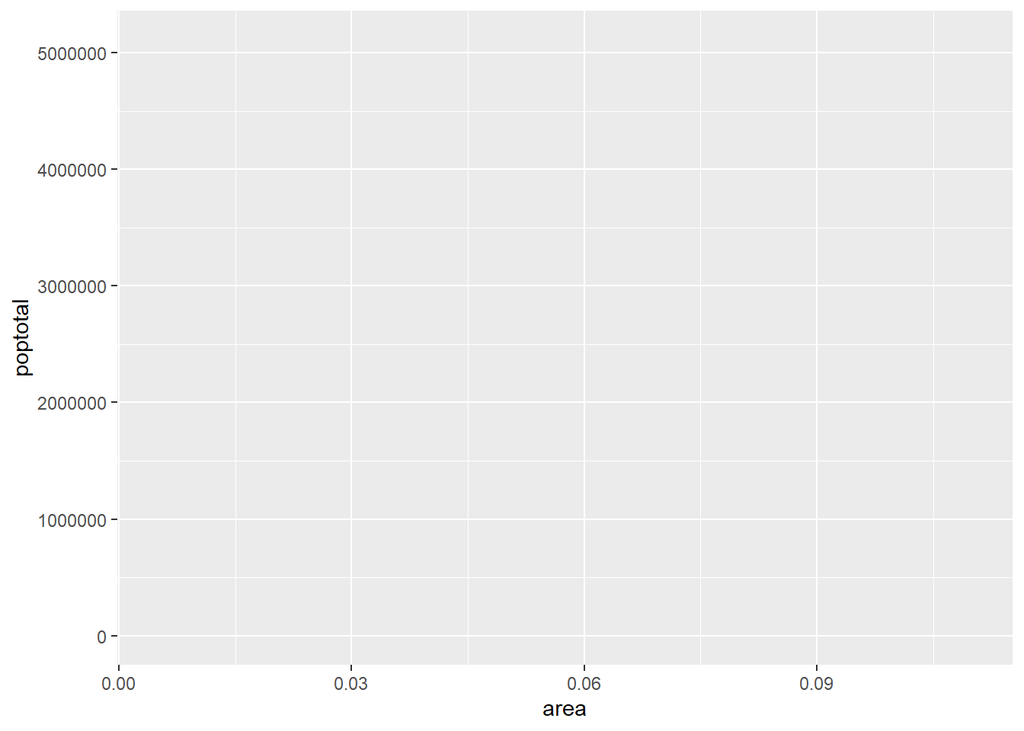

```r
# Setup
options(scipen=999)  # turn off scientific notation like 1e+06
library(ggplot2)
data("midwest", package = "ggplot2")  # load the data
# midwest <- read.csv("http://goo.gl/G1K41K") # alt source

# Init Ggplot
ggplot(midwest, aes(x=area, y=poptotal))  # area and poptotal are columns in 'midwest'
```

绘制了一个空白的ggplot。尽管指定了x和y，但里面没有点或线。这是因为，gggplot并不认为你的意思是要画一个散点图或线图。我只告诉了ggplot使用什么数据集，X轴和Y轴应该使用什么列。我没有明确要求它绘制任何点。

另外要注意的是，aes()函数是用来指定X轴和Y轴的。这是因为，任何作为源数据框的一部分的信息都必须在 aes()函数中指定。

## 如何做一个简单的散点图

让我们在空白的ggplot上面做一个散点图，用一个叫geom_point的geom图层来添加点。

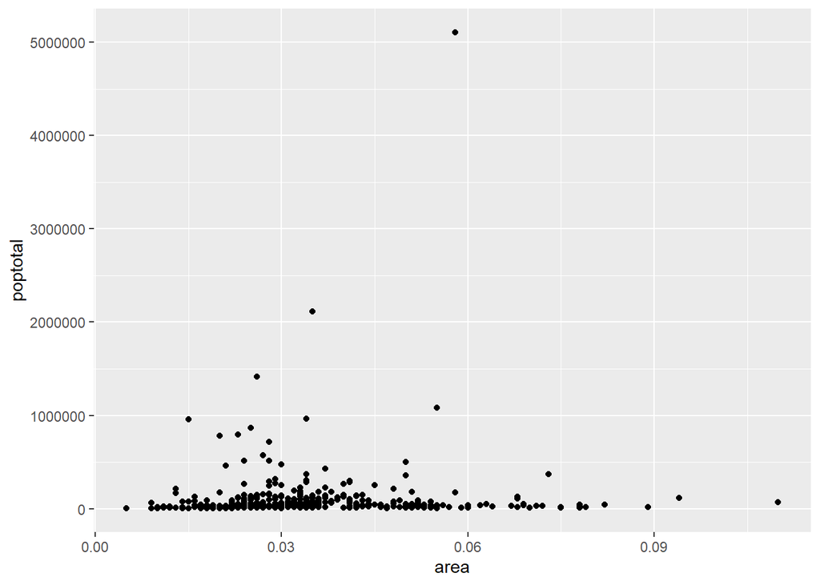

```r
library(ggplot2)
ggplot(midwest, aes(x=area, y=poptotal)) + geom_point()
```

我们得到了一个基本的散点图，每个点代表一个县。然而，它缺乏一些基本的组件，比如情节标题，有意义的轴标签等。此外，大部分的点都集中在图的底部，这并不是很好。在接下来的步骤中，你将看到如何纠正这些问题。

就像geom_point()一样，有很多这样的geom图层，我们将在本教程系列的后续章节中看到。现在，让我们使用geom_smooth(method=‘lm’)来添加一个平滑图层。由于该方法被设置为 lm（线性模型的缩写），所以它绘制了最佳拟合线。

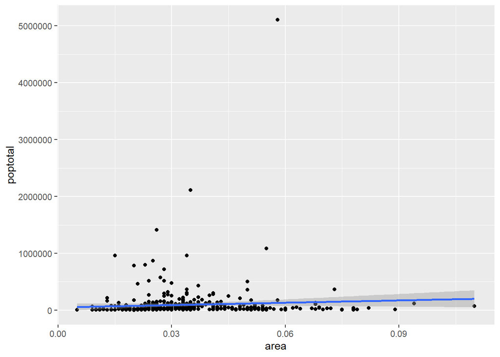

```r
library(ggplot2)
g <- ggplot(midwest, aes(x=area, y=poptotal)) + geom_point() + geom_smooth(method="lm")
plot(g)
```

最佳拟合线是蓝色的。能否找出geom_smooth的其他方法选项？(注：参见?geom_smooth）。你可能已经注意到了，大部分的点位于图表的底部，这看起来并不美观。所以，让我们改变Y轴的限制，把重点放在下半部分。

## 调整X轴和Y轴限制

X轴和Y轴的限制可以通过2种方法来控制。

### 方法1：通过删除范围外的点。

这将改变最佳拟合线或平滑线相对于原始数据的变化。

这可以通过xlim()和ylim()来实现。你可以传递一个长度为2的数值向量（有最大值和最小值），或者只传递最大值和最小值本身。

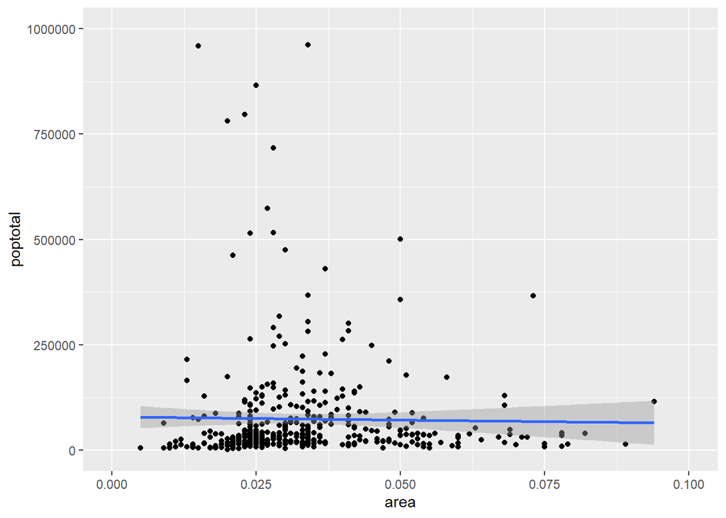

```r
library(ggplot2)
g <- ggplot(midwest, aes(x=area, y=poptotal)) + geom_point() + geom_smooth(method="lm")
# Delete the points outside the limits
g + xlim(c(0, 0.1)) + ylim(c(0, 1000000))   # deletes points
```

```r
# g + xlim(0, 0.1) + ylim(0, 1000000)   # deletes points
```

在这种情况下，图表不是从头开始建立的，而是在g的基础上建立起来的。使用 ggplot，你可以在这个情节之上添加更多的图层、主题和其他设置。

你是否注意到，与原始图谱相比，最佳拟合线变得更加水平？这是因为在使用xlim()和ylim()时，在绘制最佳拟合线时，指定范围外的点会被删除，并且不会被考虑(使用geom_smooth(method=‘lm’))。当你想知道当一些极端值(或离群值)被删除后，最佳拟合线会有什么变化时，这个功能可能会派上用场。

### 方法2：缩放

另一种方法是在不删除点的情况下，通过放大到感兴趣的区域来改变X轴和Y轴的极限。这个方法是用 coord_cartesian()来完成的。（针对某一区域缩放便于显示，其他点不可见但确实存在）

让我们把这个图形存储为g1。

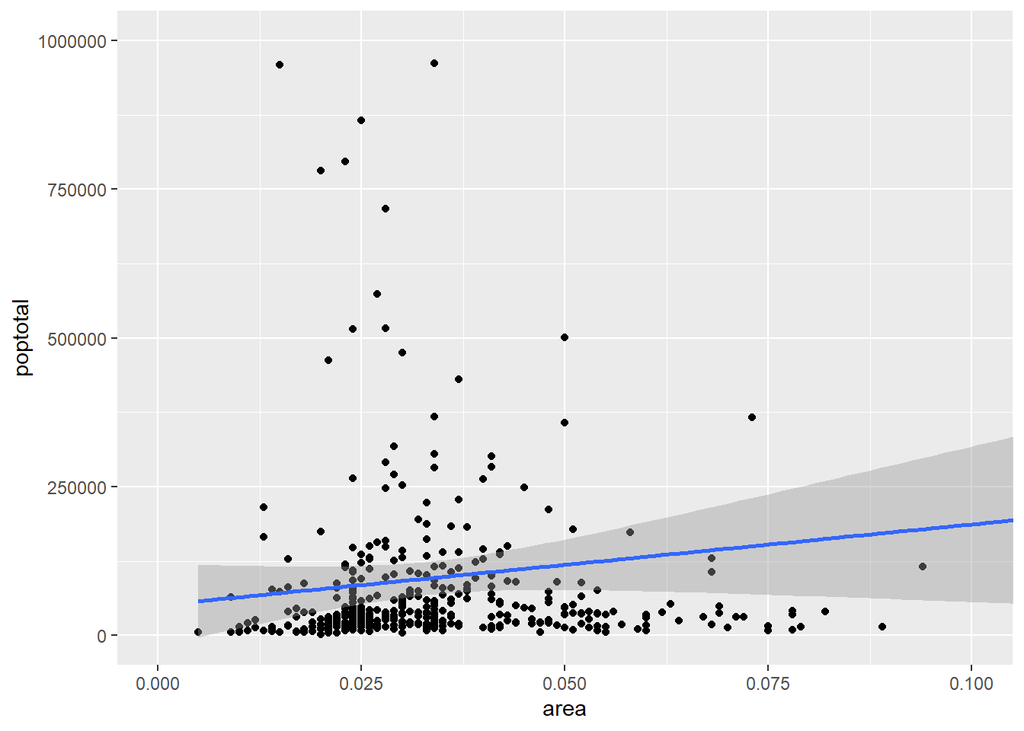

```r
library(ggplot2)
g <- ggplot(midwest, aes(x=area, y=poptotal)) + geom_point() + geom_smooth(method="lm")
# Zoom in without deleting the points outside the limits.
# As a result, the line of best fit is the same as the original plot.
g1 <- g + coord_cartesian(xlim=c(0,0.1), ylim=c(0, 1000000))  # zooms in
plot(g1)
```

由于考虑了所有的点，最佳拟合线没有改变。

## 如何更改标题和轴的标签

我将其存储为g1。让我们为X轴和Y轴添加绘图标题和标签。这可以用带title、x和y参数的labs()函数一次完成。另一种方法是使用gtitle()、xlab()和ylab()。

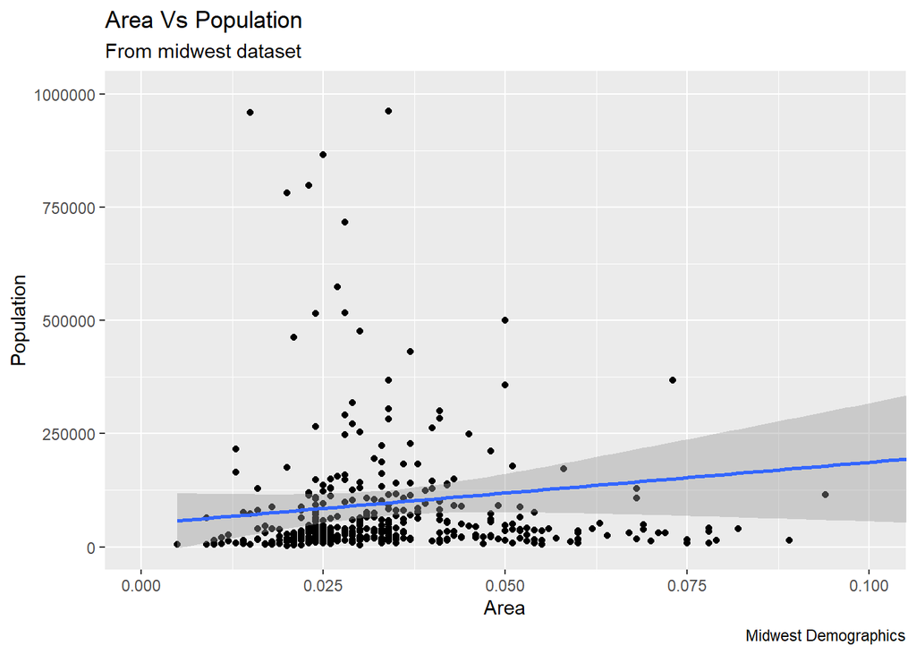

```r
library(ggplot2)
g <- ggplot(midwest, aes(x=area, y=poptotal)) + geom_point() + geom_smooth(method="lm")

g1 <- g + coord_cartesian(xlim=c(0,0.1), ylim=c(0, 1000000))  # zooms in

# Add Title and Labels
g1 + labs(title="Area Vs Population", subtitle="From midwest dataset", y="Population", x="Area", caption="Midwest Demographics")
```

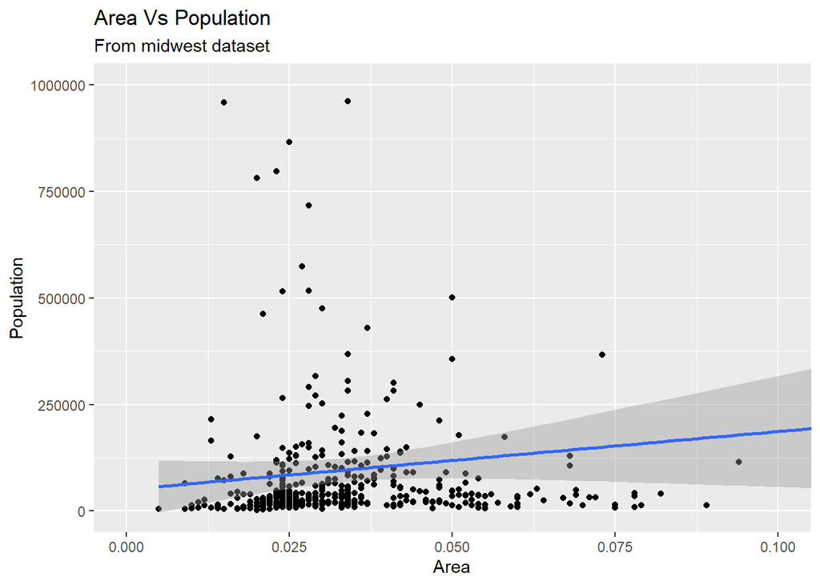

```r
# or

g1 + ggtitle("Area Vs Population", subtitle="From midwest dataset") + xlab("Area") + ylab("Population")
```

看起来还不错！

## 如何改变点数的颜色和大小

### 如何将颜色和大小改成静态？

我们可以通过修改相应的geom图层，来改变geom的美学映射。让我们把点和线的颜色改成静态值。

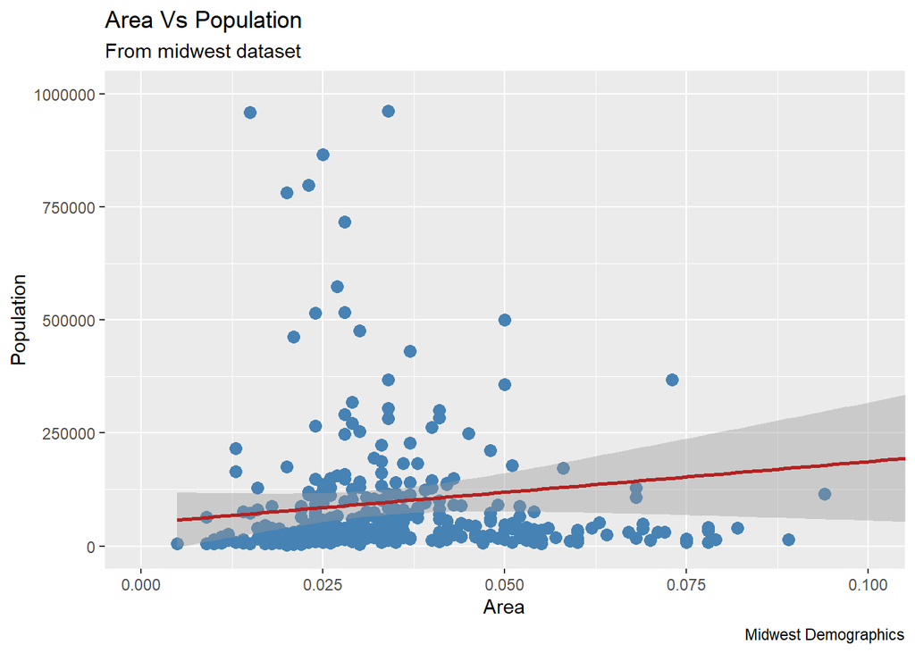

```r
library(ggplot2)
ggplot(midwest, aes(x=area, y=poptotal)) +
  geom_point(col="steelblue", size=3) +   # 数据点的颜色与大小,geom_point添加了点图层，因此其设置也在这里完成
  geom_smooth(method="lm", col="firebrick") +  # 线的颜色；添加了线图层，同上
  coord_cartesian(xlim=c(0, 0.1), ylim=c(0, 1000000)) +
  labs(title="Area Vs Population", subtitle="From midwest dataset", y="Population", x="Area", caption="Midwest Demographics")
```

### 如何改变颜色来反映另一列中的分类？

假设我们想让颜色根据源数据集中的另一列(midwest)来改变颜色，必须在 aes()中指定。

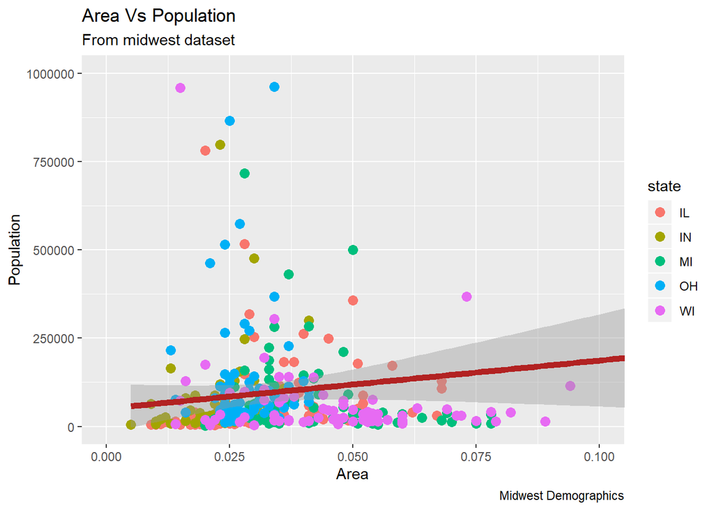

```r
library(ggplot2)
gg <- ggplot(midwest, aes(x=area, y=poptotal)) +
  geom_point(aes(col=state), size=3) +  # 数据点的颜色与大小,geom_point添加了点图层，因此其设置也在这里完成
  geom_smooth(method="lm", col="firebrick", size=2) +
  coord_cartesian(xlim=c(0, 0.1), ylim=c(0, 1000000)) +
  labs(title="Area Vs Population", subtitle="From midwest dataset", y="Population", x="Area", caption="Midwest Demographics")
plot(gg)
```

现在，每个点的颜色是根据它所属的状态来确定的，因为设置了aes(col=state)。不仅仅是颜色，还可以用size, shape, stroke（边界的厚度）和fill（填充颜色）来区分分组。

作为一个额外的好处，图例是自动添加的。如果需要的话，可以通过在主题()函数中设置llegend.position为None来移除。

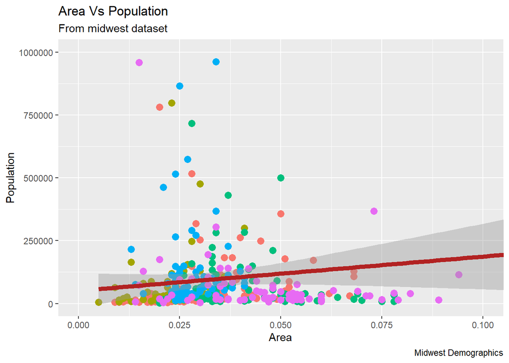

```r
gg + theme(legend.position="None")  #
```

另外，你可以完全改变调色板的颜色。

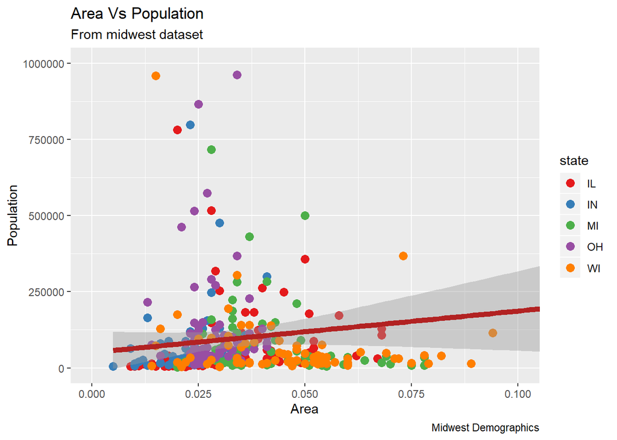

```r
gg + scale_colour_brewer(palette = "Set1")
```

更多这样的调色板可以在RColorBrewer包中找到。

```r
library(RColorBrewer)
head(brewer.pal.info, 5)
```

```
##      maxcolors category colorblind
## BrBG        11      div       TRUE
## PiYG        11      div       TRUE
## PRGn        11      div       TRUE
## PuOr        11      div       TRUE
## RdBu        11      div       TRUE
```

## 如何改变X轴的文字和刻度线位置

### 如何修改X轴和Y轴文字及其位置？

好了，现在我们来看看如何改变X轴和Y轴的文字及其位置。这涉及到两个方面：分隔符和标签。

#### 步骤1：设置分隔符

```
断点应该与X轴变量的比例相同。注意，我使用scale_x_continuous，因为X轴变量是一个连续变量。如果它是一个日期变量，可以使用scale_x_date。就像scale_x_continuous()一样，在Y轴上也有一个等效的scale_y_continuous()。
```

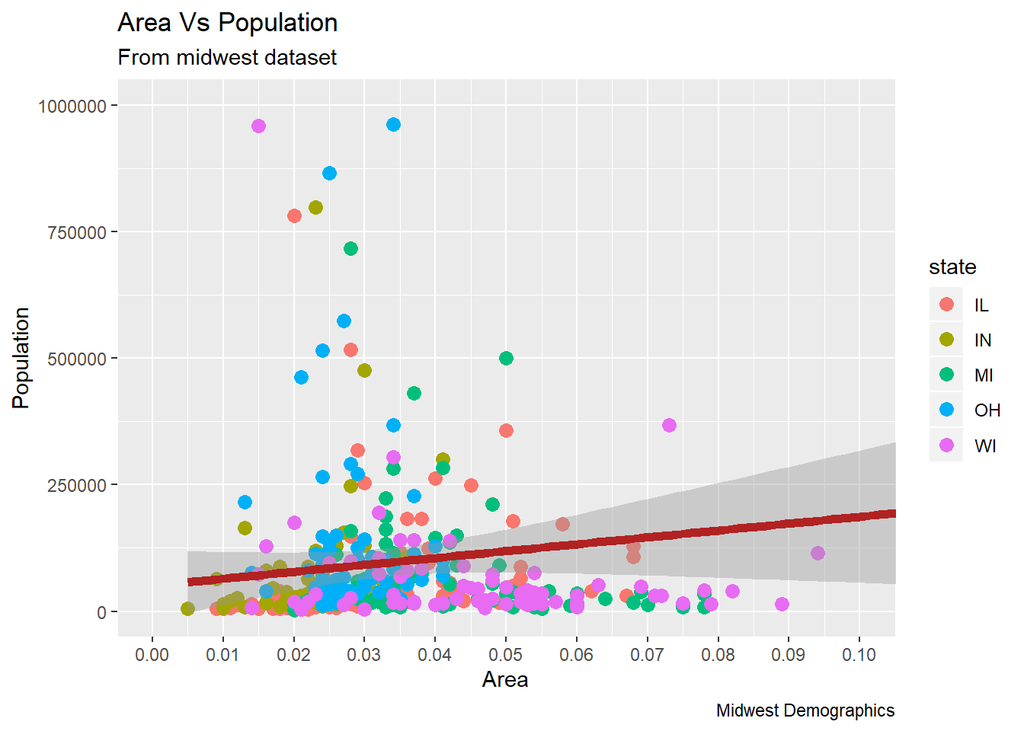

```r
library(ggplot2)

# Base plot
gg <- ggplot(midwest, aes(x=area, y=poptotal)) +
  geom_point(aes(col=state), size=3) +  # Set color to vary based on state categories.
  geom_smooth(method="lm", col="firebrick", size=2) +
  coord_cartesian(xlim=c(0, 0.1), ylim=c(0, 1000000)) +
  labs(title="Area Vs Population", subtitle="From midwest dataset", y="Population", x="Area", caption="Midwest Demographics")

# Change breaks
gg + scale_x_continuous(breaks=seq(0, 0.1, 0.01))
```

#### 第2步：改变标签

你可以在轴的刻度线处选择改变标签，标签的长度与断点的长度相同。

让我通过将标签设置为从a到k的字母（在这里没有任何实际意义）来演示。

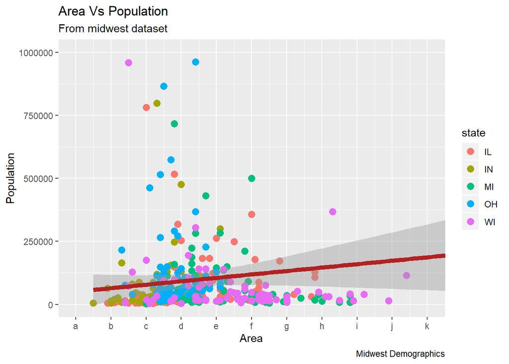

```r
library(ggplot2)

# Base plot
gg <- ggplot(midwest, aes(x=area, y=poptotal)) +
  geom_point(aes(col=state), size=3) +  # Set color to vary based on state categories.
  geom_smooth(method="lm", col="firebrick", size=2) +
  coord_cartesian(xlim=c(0, 0.1), ylim=c(0, 1000000)) +
  labs(title="Area Vs Population", subtitle="From midwest dataset", y="Population", x="Area", caption="Midwest Demographics")

# Change breaks
gg + scale_x_continuous(breaks=seq(0, 0.1, 0.01), labels = letters[1:11])
```

如果你需要反转比例（倒序排列轴标签），请使用scale_x_reverse()。

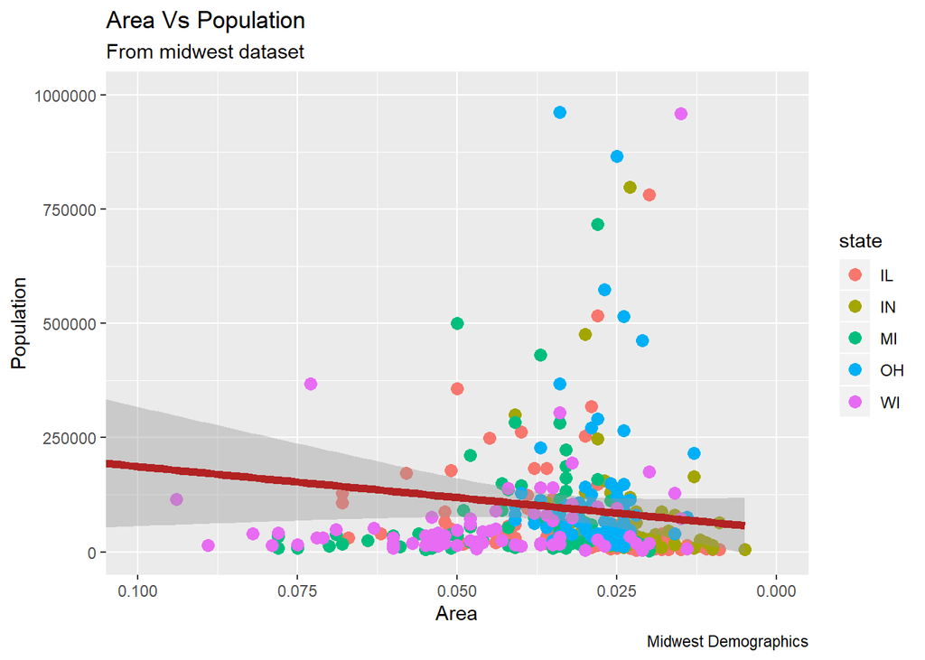

```r
library(ggplot2)
gg <- ggplot(midwest, aes(x=area, y=poptotal)) +
  geom_point(aes(col=state), size=3) +  # Set color to vary based on state categories.
  geom_smooth(method="lm", col="firebrick", size=2) +
  coord_cartesian(xlim=c(0, 0.1), ylim=c(0, 1000000)) +
  labs(title="Area Vs Population", subtitle="From midwest dataset", y="Population", x="Area", caption="Midwest Demographics")

# Reverse X Axis Scale
gg + scale_x_reverse()
```

## 如何通过格式化原始值来编写轴标签的自定义格式文本？

让我们把Y轴文本也设置好，并对X轴和Y轴标签进行格式化。我使用了2种方法来格式化标签。 #### 方法一：使用sprintf()。(在下面的例子中已经格式化为%) #### 方法2：使用自定义的用户定义的函数。(格式化为1000到1K的比例)

无论哪种方法，都可以使用，觉得方便就用哪种方法。

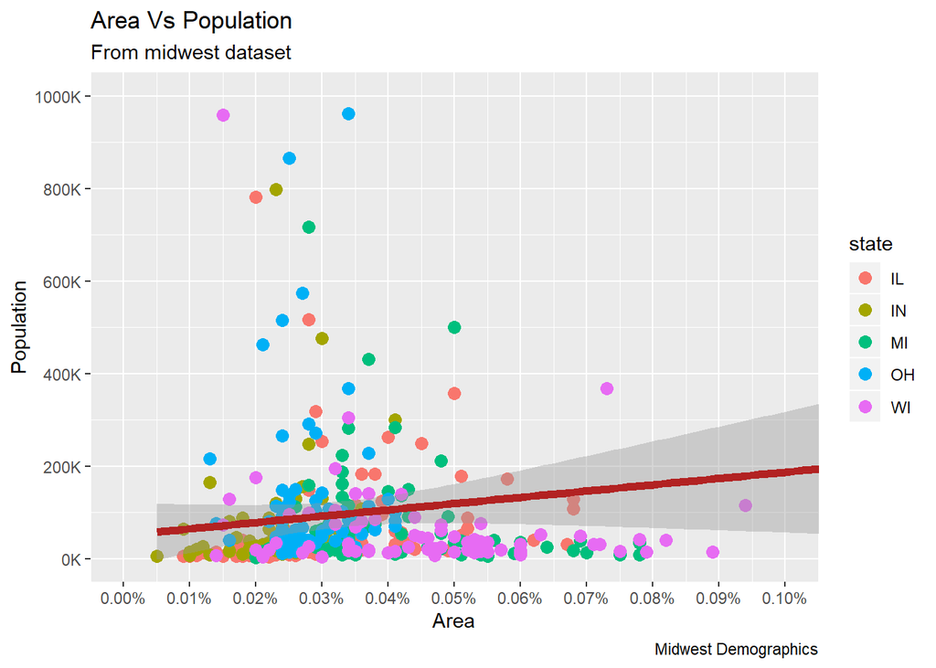

```r
library(ggplot2)
gg <- ggplot(midwest, aes(x=area, y=poptotal)) +
  geom_point(aes(col=state), size=3) +  # Set color to vary based on state categories.
  geom_smooth(method="lm", col="firebrick", size=2) +
  coord_cartesian(xlim=c(0, 0.1), ylim=c(0, 1000000)) +
  labs(title="Area Vs Population", subtitle="From midwest dataset", y="Population", x="Area", caption="Midwest Demographics")

# Change Axis Texts
gg + scale_x_continuous(breaks=seq(0, 0.1, 0.01), labels = sprintf("%1.2f%%", seq(0, 0.1, 0.01))) +
  scale_y_continuous(breaks=seq(0, 1000000, 200000), labels = function(x){paste0(x/1000, 'K')})
```

我们从中西部数据集的人口与面积的散点图开始。点的颜色和大小分别根据状态（分类）和人口密度（连续）列而变化。我们在之前的gggplot2教程中已经做了类似的工作。

下图中，标题、轴标签和图例等基本组件都设置得很好。但是，如何修改外观呢？

大多数与外观相关的要求都可以通过使用theme()函数来实现。它可以接受大量的参数。

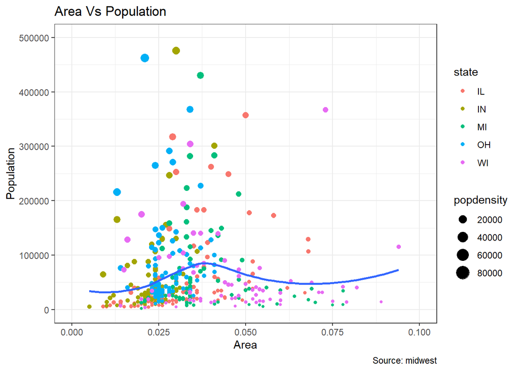

```r
options(scipen=999)
library(ggplot2)
data("midwest", package = "ggplot2")
ggplot(midwest, aes(x=area, y=poptotal)) +
  geom_point(aes(col=state, size=popdensity)) +
  geom_smooth(method="loess", se=F) + xlim(c(0, 0.1)) + ylim(c(0, 500000)) +
  labs(title="Area Vs Population", y="Population", x="Area", caption="Source: midwest")+
  theme_bw()
```

传给主题()组件的参数需要使用特殊的 element_type()函数来设置。它们有4种主要类型。

element_text()。由于标题、副标题和标题都是文本项，所以需要使用 element_text()函数来设置。 element_line()函数用于修改基于线条的组件，如轴线、主次网格线等。 element_rect(): 修改矩形组件，如绘图和面板背景等。 element_blank()：用于关闭显示主题项。

在接下来的讨论中会有更多的内容。

让我们从修改标题和轴文本开始，讨论一些与修改情节输出相关的任务。

## 添加图层和轴标题

小区和轴的标题和轴的文字都是小区主题的一部分。因此，可以使用主题()函数进行修改。theme()函数接受上面提到的四个 element_type()函数中的一个作为参数。由于情节和轴的标题是文本组件，所以用 element_text()函数来修改。

下面，我对其大小、颜色、面和行高进行了修改。轴文本可以通过改变角度来旋转。

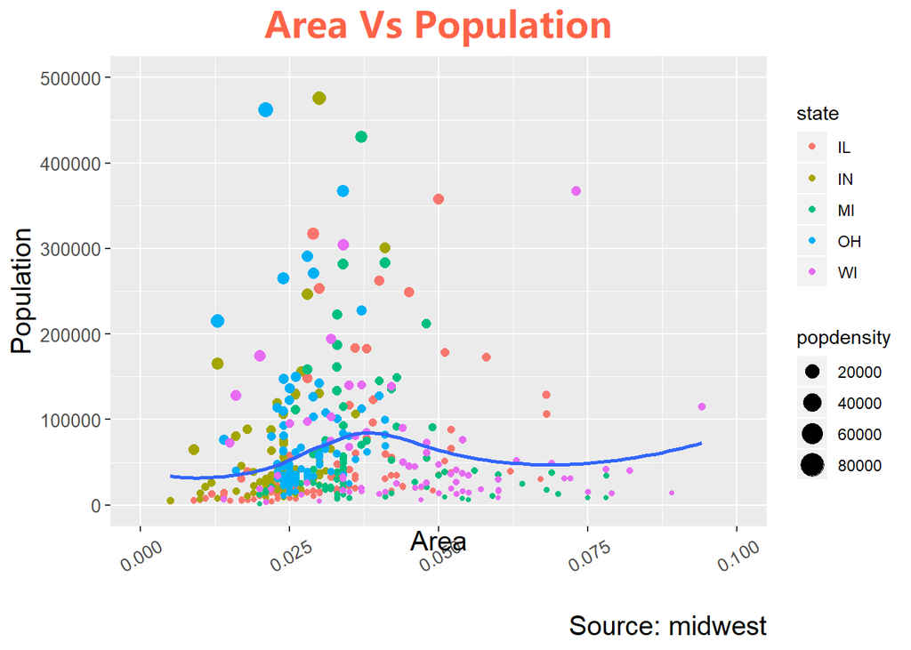

```r
library(ggplot2)

# Base Plot
gg <- ggplot(midwest, aes(x=area, y=poptotal)) +
  geom_point(aes(col=state, size=popdensity)) +
  geom_smooth(method="loess", se=F) + xlim(c(0, 0.1)) + ylim(c(0, 500000)) +
  labs(title="Area Vs Population", y="Population", x="Area", caption="Source: midwest")

# Modify theme components -------------------------------------------
windowsFonts(myFont = windowsFont("微软雅黑"))
gg + theme(plot.title=element_text(size=20,
                                    face="bold",
                                    family="myFont",
                                    color="tomato",
                                    hjust=0.5,
                                    lineheight=1.2),  # title
            plot.subtitle=element_text(size=15,
                                       family="myFont",
                                       face="bold",
                                       hjust=0.5),  # subtitle
            plot.caption=element_text(size=15),  # caption
            axis.title.x=element_text(vjust=10,
                                      size=15),  # X axis title
            axis.title.y=element_text(size=15),  # Y axis title
            axis.text.x=element_text(size=10,
                                     angle = 30,
                                     vjust=.5),  # X axis text
            axis.text.y=element_text(size=10))  # Y axis text
```

vjust，控制标题（或标签）和绘图之间的垂直间距。 hjust，控制水平间距。设置为0.5，使标题居中。 family，用于设置一个新的字体 face，设置字体名称（“素色”、“斜体”、“粗体”、“粗体”、“bold.斜体”）。

上面的例子涵盖了一些经常使用的主题修改;如果你想改变任何组件的外观，theme是你要看的第一个地方。

## 修改图例

每当你的绘图的geom(如点、线、条形等)被设置为基于另一列的美映射学(填充、大小、颜色、形状或笔画)时，就会自动绘制一个图例。

如果你创建的geom是静态的，默认情况下不会绘制一个图例。在这种情况下，你可能需要手动创建自己的图例。下面的例子是针对自动创建图例的情况。 ### 如何更改图例标题

现在我们来改一下图例标题。我们有两个图例，颜色和大小各一个。尺寸是基于连续变量，而颜色是基于分类（离散）变量。

有3种方法可以改变图例标题。 方法一：使用 labs()

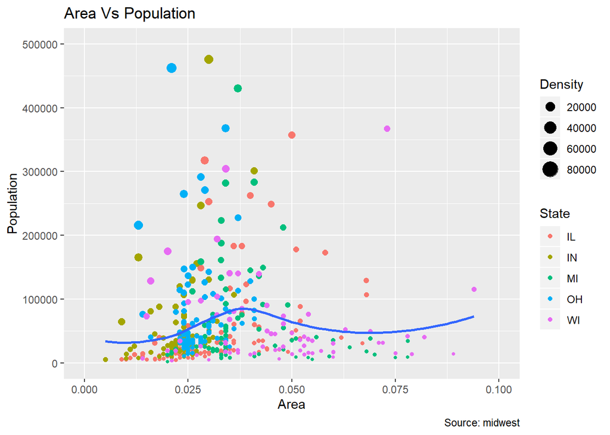

```r
library(ggplot2)

# Base Plot
gg <- ggplot(midwest, aes(x=area, y=poptotal)) +
  geom_point(aes(col=state, size=popdensity)) +
  geom_smooth(method="loess", se=F) + xlim(c(0, 0.1)) + ylim(c(0, 500000)) +
  labs(title="Area Vs Population", y="Population", x="Area", caption="Source: midwest")

gg + labs(color="State", size="Density")  # modify legend title
```

方法二：使用 guides()

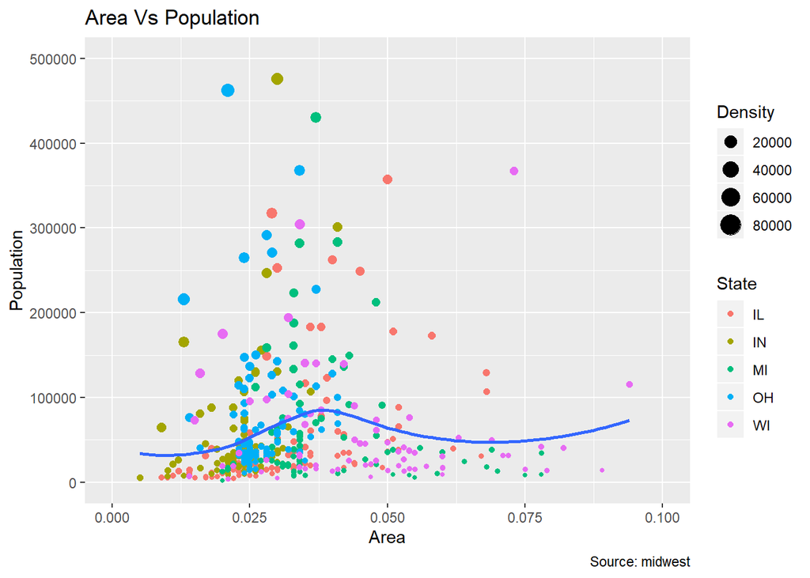

```r
library(ggplot2)

# Base Plot
gg <- ggplot(midwest, aes(x=area, y=poptotal)) +
  geom_point(aes(col=state, size=popdensity)) +
  geom_smooth(method="loess", se=F) + xlim(c(0, 0.1)) + ylim(c(0, 500000)) +
  labs(title="Area Vs Population", y="Population", x="Area", caption="Source: midwest")

gg <- gg + guides(color=guide_legend("State"), size=guide_legend("Density"))  # modify legend title
plot(gg)
```

方法三：使用scale_aesthetic_vartype()格式

scale_aestheic_vartype()的格式允许你关闭一个特定的美学图例，而其他的则保留。这只需设置 guide=FALSE即可完成。例如，如果图例是基于连续变量的点的大小，那么scale_size_continuous()就是合适的函数。

你能猜到如果你有一个形状的图例，并且是基于分类变量，应该使用什么函数吗？

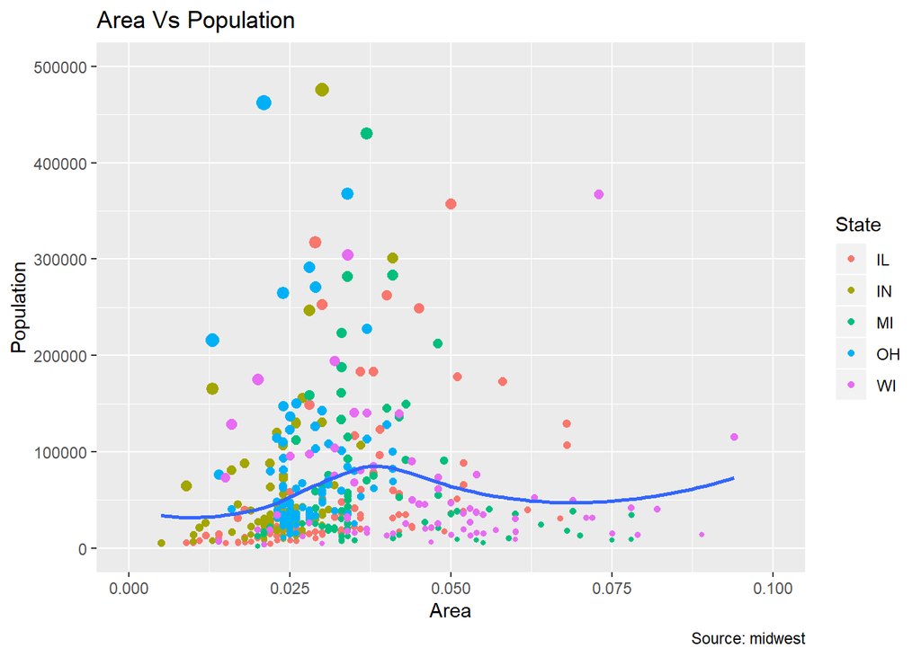

```r
library(ggplot2)

# Base Plot
gg <- ggplot(midwest, aes(x=area, y=poptotal)) +
  geom_point(aes(col=state, size=popdensity)) +
  geom_smooth(method="loess", se=F) + xlim(c(0, 0.1)) + ylim(c(0, 500000)) +
  labs(title="Area Vs Population", y="Population", x="Area", caption="Source: midwest")

# Modify Legend
gg + scale_color_discrete(name="State") + scale_size_continuous(name = "Density", guide = FALSE)  # turn off legend for size
```

### 如何更改类别的图例标签和点颜色

这可以使用相应的scale_aesthetic_manual()函数来完成。新的图例标签作为一个字符向量提供给标签参数。如果你想改变类别的颜色，可以将其分配到value参数中，如下图所示。

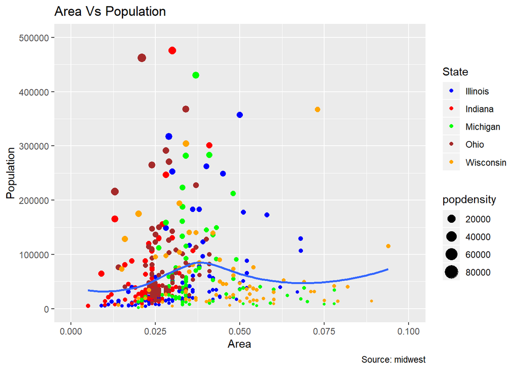

```r
library(ggplot2)

# Base Plot
gg <- ggplot(midwest, aes(x=area, y=poptotal)) +
  geom_point(aes(col=state, size=popdensity)) +
  geom_smooth(method="loess", se=F) + xlim(c(0, 0.1)) + ylim(c(0, 500000)) +
  labs(title="Area Vs Population", y="Population", x="Area", caption="Source: midwest")

gg + scale_color_manual(name="State", #修改颜色，则aesthetic=color
                        labels = c("Illinois",
                                   "Indiana",
                                   "Michigan",
                                   "Ohio",
                                   "Wisconsin"),
                        values = c("IL"="blue",
                                   "IN"="red",
                                   "MI"="green",
                                   "OH"="brown",
                                   "WI"="orange"))
```

### 改变图例的顺序

如果你想在size (Density)之后显示 color (State)的图例，可以通过guides()函数来完成。图例的顺序会根据需要进行设置。

如果你想改变图例中标签的位置，请看前面的例子中的顺序设置。

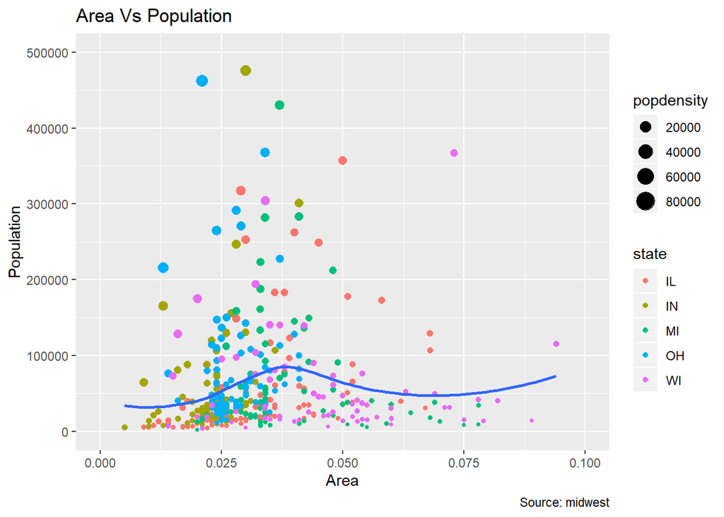

```r
library(ggplot2)

# Base Plot
gg <- ggplot(midwest, aes(x=area, y=poptotal)) +
  geom_point(aes(col=state, size=popdensity)) +
  geom_smooth(method="loess", se=F) + xlim(c(0, 0.1)) + ylim(c(0, 500000)) +
  labs(title="Area Vs Population", y="Population", x="Area", caption="Source: midwest")

gg + guides(colour = guide_legend(order = 2),
            size = guide_legend(order = 1))
```

### 如何设置标题、文字和关键字的样式

还可以调整图例标题、文字、key和指示的样式。 图例的key是一个类似于数字的元素，所以必须使用 element_rect()函数来设置。

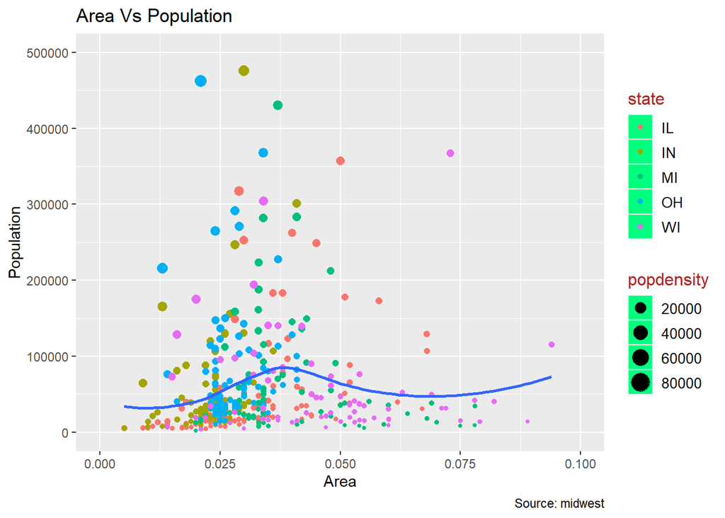

```r
library(ggplot2)

# Base Plot
gg <- ggplot(midwest, aes(x=area, y=poptotal)) +
  geom_point(aes(col=state, size=popdensity)) +
  geom_smooth(method="loess", se=F) + xlim(c(0, 0.1)) + ylim(c(0, 500000)) +
  labs(title="Area Vs Population", y="Population", x="Area", caption="Source: midwest")

gg + theme(legend.title = element_text(size=12, color = "firebrick"),
           legend.text = element_text(size=10),
           legend.key=element_rect(fill='springgreen'))
```

### 如何删除图例和更改图例位置？

图例在剧情中的位置是主题的一个方面。所以可以使用主题()函数来修改它。如果你想把图例放置在图形内部，可以另外使用 legend.justification 控制图例的铰链点。

legend.position是图表区域中的x轴和y轴的位置，其中(0,0)是图表的左下角，(1,1)是右上角。同样，图例.justification也是指图例内部的铰链点。

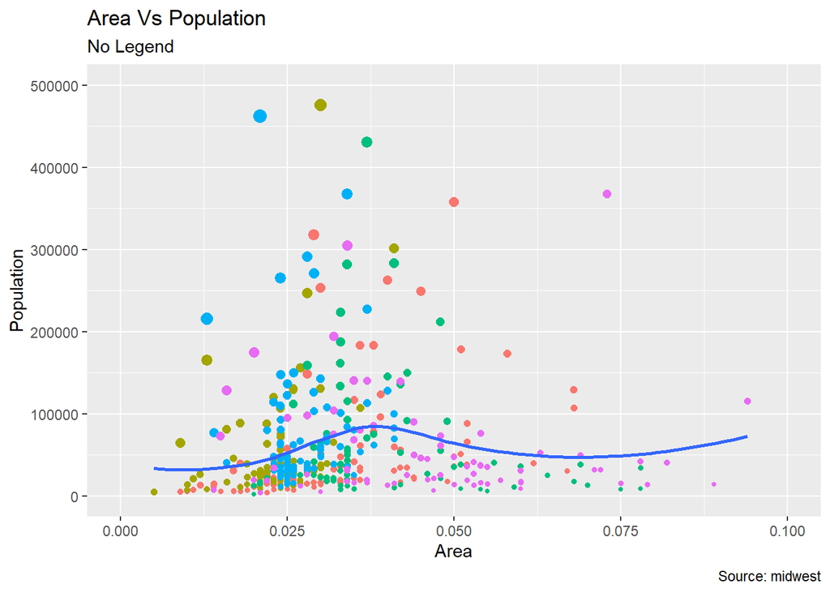

```r
library(ggplot2)

# Base Plot
gg <- ggplot(midwest, aes(x=area, y=poptotal)) +
  geom_point(aes(col=state, size=popdensity)) +
  geom_smooth(method="loess", se=F) + xlim(c(0, 0.1)) + ylim(c(0, 500000)) +
  labs(title="Area Vs Population", y="Population", x="Area", caption="Source: midwest")

# No legend --------------------------------------------------
gg + theme(legend.position="None") + labs(subtitle="No Legend")
```

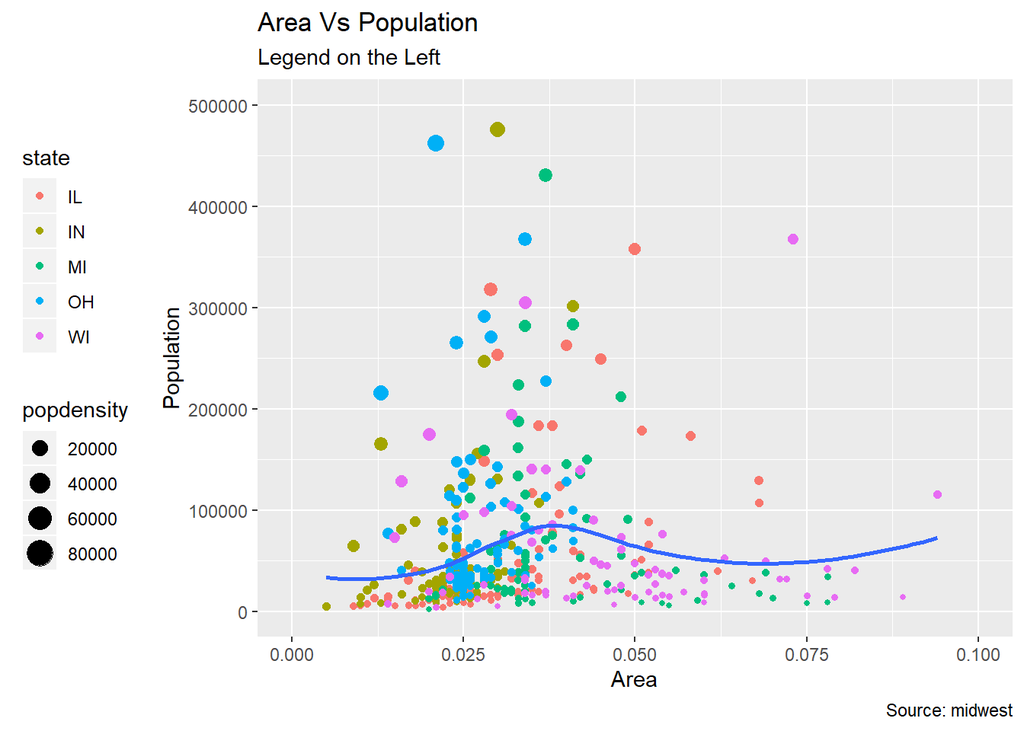

```r
# Legend to the left -----------------------------------------
gg + theme(legend.position="left") + labs(subtitle="Legend on the Left")
```

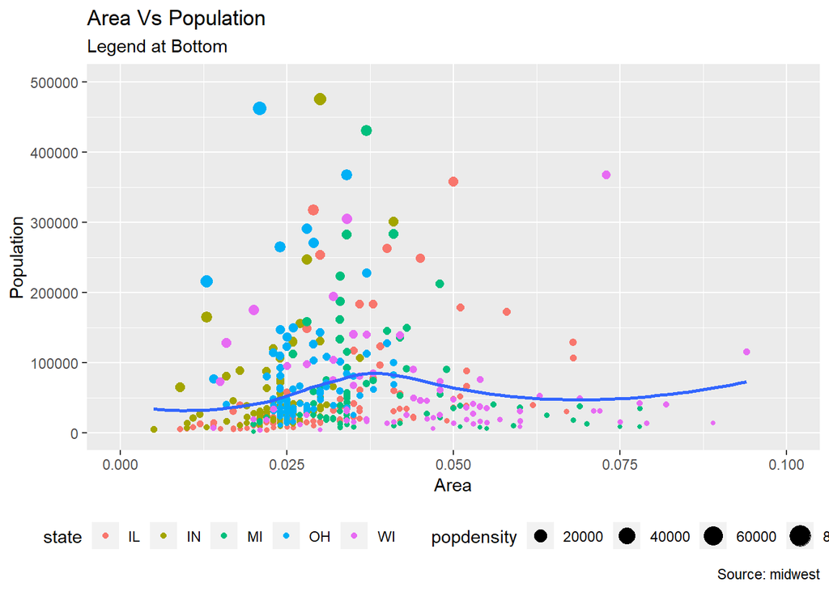

```r
# legend at the bottom and horizontal ------------------------
gg + theme(legend.position="bottom", legend.box = "horizontal") + labs(subtitle="Legend at Bottom")
```

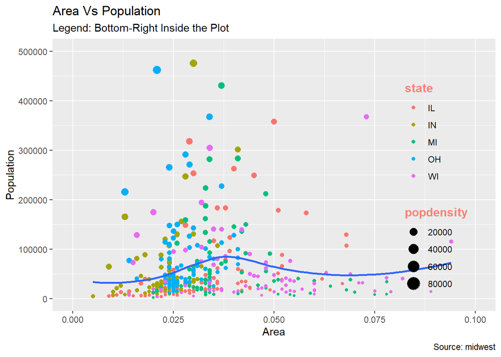

```r
# legend at bottom-right, inside the plot --------------------
gg + theme(legend.title = element_text(size=12, color = "salmon", face="bold"),
           legend.justification=c(1,0),
           legend.position=c(0.95, 0.05),
           legend.background = element_blank(),
           legend.key = element_blank()) +
  labs(subtitle="Legend: Bottom-Right Inside the Plot")
```

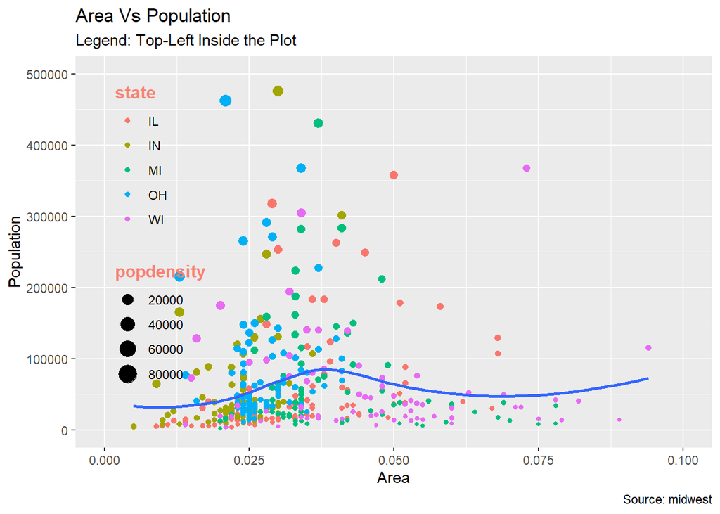

```r
# legend at top-left, inside the plot -------------------------
gg + theme(legend.title = element_text(size=12, color = "salmon", face="bold"),
           legend.justification=c(0,1),
           legend.position=c(0.05, 0.95),
           legend.background = element_blank(),
           legend.key = element_blank()) +
  labs(subtitle="Legend: Top-Left Inside the Plot")
```

### 如何在Plot内部任意添加注释

让我们来看看如何给图表中的任何一个特定点添加注释。它可以通过 annotation_custom()函数来完成，该函数将一个 grob 作为参数。所以，让我们创建一个grob来保存你想使用网格包显示的文本。

[figure not shown]

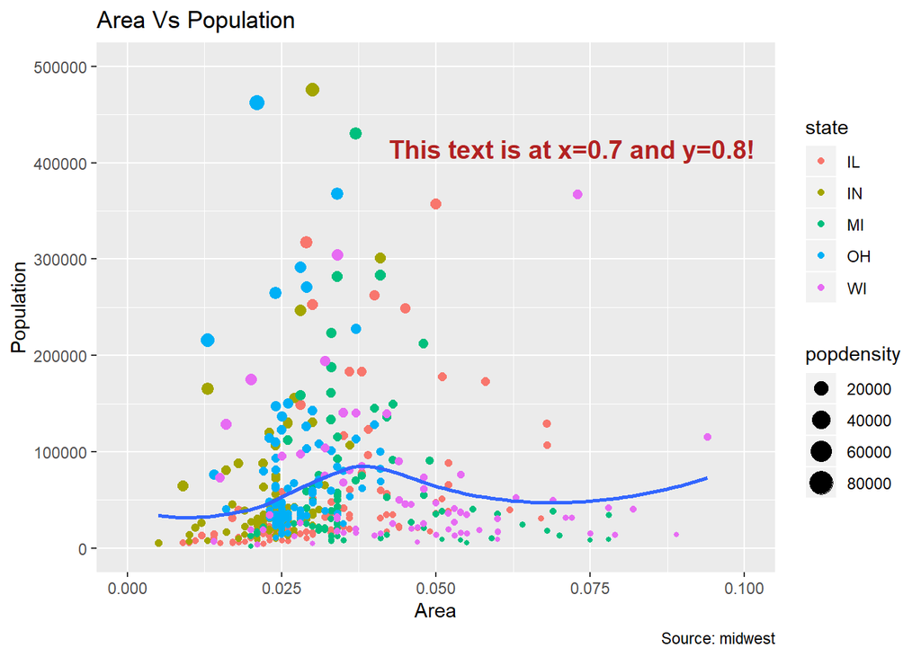

```r
library(ggplot2)

# Base Plot
gg <- ggplot(midwest, aes(x=area, y=poptotal)) +
  geom_point(aes(col=state, size=popdensity)) +
  geom_smooth(method="loess", se=F) + xlim(c(0, 0.1)) + ylim(c(0, 500000)) +
  labs(title="Area Vs Population", y="Population", x="Area", caption="Source: midwest")


library(grid)
my_text = "This text is at x=0.7 and y=0.8!"

gg + annotation_custom(grid.text(my_text, x=0.7,  y=0.8, gp=gpar(col="firebrick", fontsize=14, fontface="bold")))
```